# STATS-PRELIM-STRUCT-EPLOITATION

# 1 Overview

For these exploratory runs there were 100 objectives to optimize, all with the target of 100 and an accuracy requirement of 99%. The population was size 512, and there was a point mutation probability of .7% at each objective. **A solution is considered optimal if all of its traits meet the accuracy requirement.**

# 2 Mu Lambda Selection

## 2.1 Best Performance Found

We look at the best performances found throughout an evolutionary run to see if there is any differences in performances found.

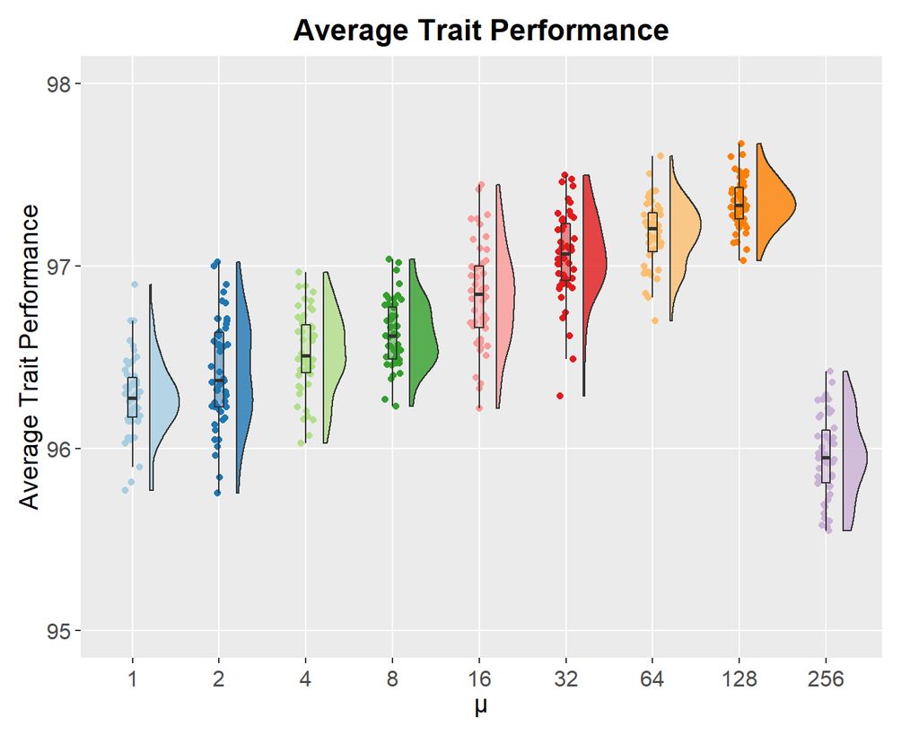

### 2.1.1 Stats Tests

The Kuskal-Wallis test finds evidence that groups do not come from the same distribution.

```r
kruskal.test(val ~ trt, data = df)
```

```
##
##  Kruskal-Wallis rank sum test
##
## data:  val by trt
## Kruskal-Wallis chi-squared = 353.41, df = 8, p-value < 2.2e-16
```

We find evidence that 128 statictically greater, in terms of better performances found.

```r
pairwise.wilcox.test(x = df$val, g = df$trt, p.adjust.method = "bonferroni", paired = FALSE, conf.int = TRUE, conf.level = .95, alternative = 'g')
```

```
##
##  Pairwise comparisons using Wilcoxon rank sum test
##
## data:  df$val and df$trt
##
##     1       2       4       8       16      32      64      128
## 2   0.28224 -       -       -       -       -       -       -
## 4   7.5e-06 0.75570 -       -       -       -       -       -
## 8   1.1e-10 0.00504 0.66663 -       -       -       -       -
## 16  3.7e-13 5.2e-08 3.8e-06 0.00075 -       -       -       -
## 32  1.4e-15 1.1e-13 2.4e-13 7.2e-12 0.00073 -       -       -
## 64  < 2e-16 8.5e-16 5.6e-16 2.4e-15 8.5e-08 0.11402 -       -
## 128 < 2e-16 < 2e-16 < 2e-16 < 2e-16 2.3e-13 1.4e-08 3.5e-05 -
## 256 1.00000 1.00000 1.00000 1.00000 1.00000 1.00000 1.00000 1.00000
##
## P value adjustment method: bonferroni
```

# 3 Tournament Selection

Here we explore the impact of different tournament size values on the exploitation diagnostic.

## 3.1 Best Performance Found

We look at the best performances found throughout an evolutionary run to see if there is any differences in performances found.

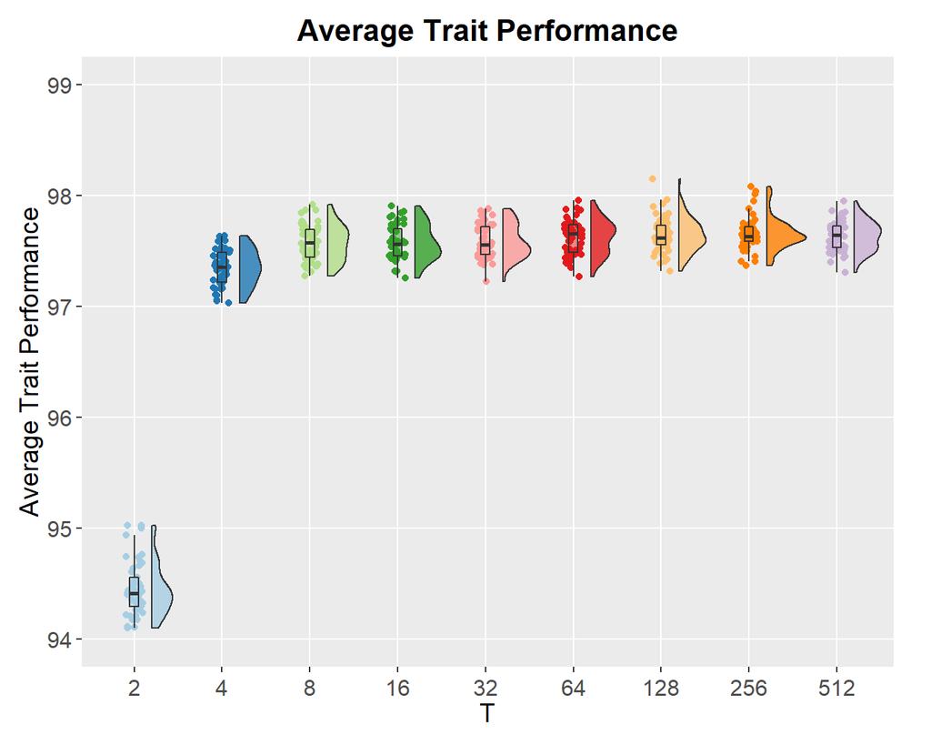

### 3.1.1 Stats Tests

The Kuskal-Wallis test finds evidence that groups do not come from the same distribution.

```r
df = filter(df, trt != 2 & trt != 4)
kruskal.test(val ~ trt, data = df)
```

```
##
##  Kruskal-Wallis rank sum test
##
## data:  val by trt
## Kruskal-Wallis chi-squared = 14.093, df = 6, p-value = 0.02861
```

We see that there is no difference in performances found for sizes after 8, in terms of better performances found.

```r
pairwise.wilcox.test(x = df$val, g = df$trt, p.adjust.method = "bonferroni", paired = FALSE, conf.int = TRUE, conf.level = .95, alternative = 't')
```

```
##
##  Pairwise comparisons using Wilcoxon rank sum test
##
## data:  df$val and df$trt
##
##     8    16   32   64   128  256
## 16  1.00 -    -    -    -    -
## 32  1.00 1.00 -    -    -    -
## 64  1.00 1.00 1.00 -    -    -
## 128 0.87 0.46 0.99 1.00 -    -
## 256 0.54 0.15 0.40 1.00 1.00 -
## 512 1.00 0.86 1.00 1.00 1.00 1.00
##
## P value adjustment method: bonferroni
```

# 4 Epsilon Lexicase Selection

Here we explore the impact of different epsilon values on the exploitation diagnostic.

## 4.1 Best Performance Found

We look at the best performances found throughout an evolutionary run to see if there is any differences in performances found.

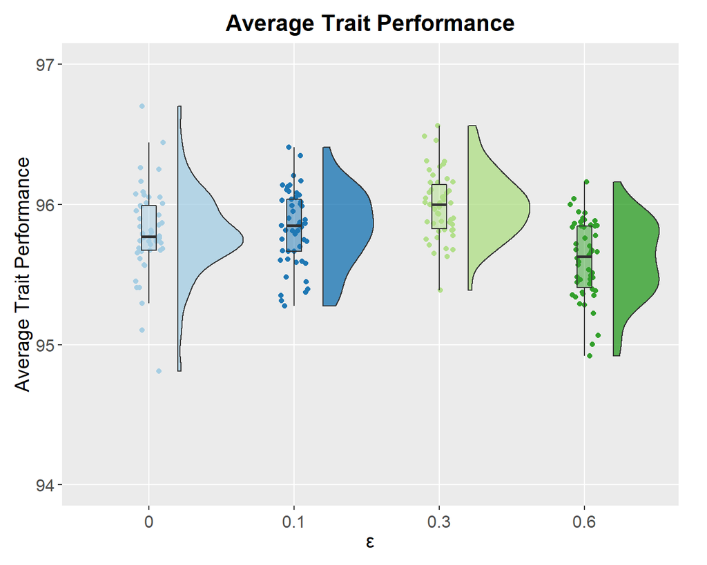

### 4.1.1 Stats Tests

The Kuskal-Wallis test finds evidence that groups do not come from the same distribution.

```r
kruskal.test(val ~ trt, data = df)
```

```
##
##  Kruskal-Wallis rank sum test
##
## data:  val by trt
## Kruskal-Wallis chi-squared = 41.662, df = 3, p-value = 4.732e-09
```

We find evidence that .3 is statictically greater than all others, in terms of better performances found.

```r
pairwise.wilcox.test(x = df$val, g = df$trt, p.adjust.method = "bonferroni", paired = FALSE, conf.int = TRUE, conf.level = .95, alternative = 'g')
```

```
##
##  Pairwise comparisons using Wilcoxon rank sum test
##
## data:  df$val and df$trt
##
##     0       0.1     0.3
## 0.1 1.00000 -       -
## 0.3 0.00095 0.01490 -
## 0.6 1.00000 1.00000 1.00000
##
## P value adjustment method: bonferroni
```

# 5 Novelty Aggregate

Here we explore the impact of different nearest neighbor values on the exploitation diagnostic.

## 5.1 Best Performance Found

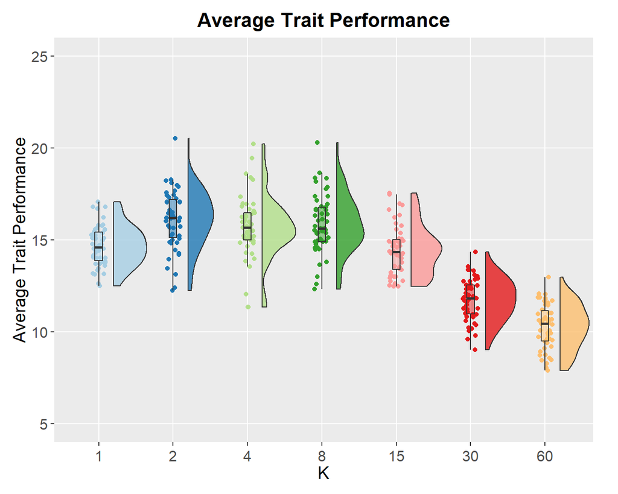

### 5.1.1 Summary Statistics

```r
do.call("rbind", tapply(df$val, df$trt, summary))
```

```
##        Min.   1st Qu.   Median     Mean  3rd Qu.    Max.
## 1  12.51120 13.874500 14.59180 14.68651 15.43093 17.0870
## 2  12.26270 15.123800 16.21140 16.09616 17.21220 20.5148
## 4  11.35600 15.008700 15.68685 15.69132 16.46950 20.2266
## 8  12.32260 14.902225 15.62450 15.88266 16.77883 20.2847
## 15 12.47140 13.399650 14.34390 14.45891 15.03460 17.5447
## 30  9.03869 10.976200 11.82250 11.74999 12.55117 14.3644
## 60  7.90888  9.498698 10.46230 10.30046 11.15692 12.9881
```

### 5.1.2 Stats Tests

The Kuskal-Wallis test finds evidence that groups do not come from the same distribution.

```r
kruskal.test(val ~ trt, data = df)
```

```
##
##  Kruskal-Wallis rank sum test
##
## data:  val by trt
## Kruskal-Wallis chi-squared = 229.18, df = 6, p-value < 2.2e-16
```

We find evidence that there is nostatistical difference between 2, 4, and 8, in terms of better performances found

```r
pairwise.wilcox.test(x = df$val, g = df$trt, p.adjust.method = "bonferroni", paired = FALSE, conf.int = TRUE, conf.level = .95, alternative = 't')
```

```
##
##  Pairwise comparisons using Wilcoxon rank sum test
##
## data:  df$val and df$trt
##
##    1       2       4       8       15      30
## 2  4.5e-05 -       -       -       -       -
## 4  0.00255 1.00000 -       -       -       -
## 8  0.00090 1.00000 1.00000 -       -       -
## 15 1.00000 1.5e-05 0.00042 0.00013 -       -
## 30 5.0e-15 2.1e-15 2.3e-14 1.5e-15 2.5e-13 -
## 60 < 2e-16 < 2e-16 7.0e-16 < 2e-16 2.3e-16 3.9e-06
##
## P value adjustment method: bonferroni
```

# 6 Fitness Sharing

Here we explore the impact of different similarity thresholds on the exploitation diagnostic.

## 6.1 Best Performance Found

We look at the best performances found throughout an evolutionary run to see if there is any differences in performances found.

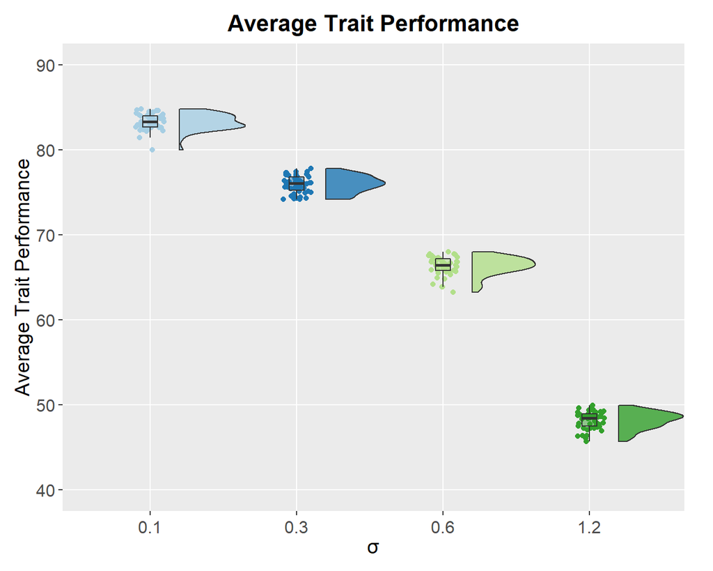

### 6.1.1 Stats Tests

The Kuskal-Wallis test finds evidence that groups do not come from the same distribution.

```r
kruskal.test(val ~ trt, data = df)
```

```
##
##  Kruskal-Wallis rank sum test
##
## data:  val by trt
## Kruskal-Wallis chi-squared = 186.57, df = 3, p-value < 2.2e-16
```

We find significant decreases in performance as the similarity threshold increases.

```r
pairwise.wilcox.test(x = df$val, g = df$trt, p.adjust.method = "bonferroni", paired = FALSE, conf.int = TRUE, conf.level = .95, alternative = 'l')
```

```
##
##  Pairwise comparisons using Wilcoxon rank sum test
##
## data:  df$val and df$trt
##
##     0.1    0.3    0.6
## 0.3 <2e-16 -      -
## 0.6 <2e-16 <2e-16 -
## 1.2 <2e-16 <2e-16 <2e-16
##
## P value adjustment method: bonferroni
```

# 7 Novelty Euclidean

## 7.1 Best Performance Found

As expected, novelty does not do well at this diagnostic.

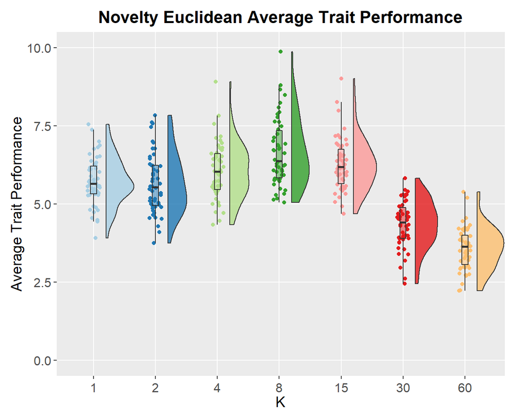

### 7.1.1 Summary Statistics

```r
do.call("rbind", tapply(df$val, df$trt, summary))
```

```
##       Min.  1st Qu.   Median     Mean  3rd Qu.    Max.
## 1  3.91000 5.327587 5.648235 5.733662 6.206132 7.54846
## 2  3.75232 4.948655 5.537465 5.655443 6.236967 7.83357
## 4  4.33933 5.464135 6.034530 6.062030 6.607525 8.90683
## 8  5.04873 5.837560 6.380315 6.657764 7.349180 9.86641
## 15 4.69221 5.655605 6.189395 6.277122 6.753067 9.00873
## 30 2.45267 3.901408 4.413530 4.351398 4.887095 5.81902
## 60 2.23390 3.068003 3.635205 3.588261 4.007000 5.39399
```

### 7.1.2 Stats Tests

The Kuskal-Wallis test finds evidence that groups do not come from the same distribution.

```r
kruskal.test(val ~ trt, data = df)
```

```
##
##  Kruskal-Wallis rank sum test
##
## data:  val by trt
## Kruskal-Wallis chi-squared = 205.34, df = 6, p-value < 2.2e-16
```

We find evidence of no statistical difference between 4,8,15, in terms of better performances found.

```r
pairwise.wilcox.test(x = df$val, g = df$trt, p.adjust.method = "bonferroni", paired = FALSE, conf.int = TRUE, conf.level = .95, alternative = 't')
```

```
##
##  Pairwise comparisons using Wilcoxon rank sum test
##
## data:  df$val and df$trt
##
##    1       2       4       8       15      30
## 2  1.00000 -       -       -       -       -
## 4  1.00000 0.50322 -       -       -       -
## 8  0.00035 0.00017 0.17931 -       -       -
## 15 0.03464 0.01716 1.00000 1.00000 -       -
## 30 2.4e-11 1.5e-08 5.0e-13 2.4e-15 6.3e-15 -
## 60 1.8e-15 1.1e-14 5.2e-16 2.4e-16 2.5e-16 2.2e-05
##
## P value adjustment method: bonferroni
```